# Analyzing German articles usage by children

Sadhana

2024-05-14

# Creating main dataframe for the task

### 1. Loading the necessary libraries.

```r
library(childesr)
library(tidyverse)
```

```r
library(ggplot2)
library(ggrepel)
```

### 2. Listing the functions in ‘childesr’ package

Since childes-db contains a set of tables, the ‘childesr’ package helps to retrieve and manipulate those tables with the help of below functions. For instance, get_collections() gives the names of available collections of corpora (“German”, “Spanish”, etc), and get_corpora() gives the names of available corpora.

```r
ls("package:childesr")
```

```
##  [1] "clear_connections"      "connect_to_childes"     "get_collections"
##  [4] "get_contexts"           "get_corpora"            "get_db_info"
##  [7] "get_participants"       "get_speaker_statistics" "get_sql_query"
## [10] "get_tokens"             "get_transcripts"        "get_types"
## [13] "get_utterances"
```

```r
collection <- get_collections()
```

```
## Using current database version: '2021.1'.
```

```r
head(collection)
```

```
## # A tibble: 6 × 3
##   collection_id collection_name data_source
##           <int> <chr>           <chr>
## 1             1 Frogs           CHILDES
## 2             2 Eng-NA          CHILDES
## 3             3 Scandinavian    CHILDES
## 4             4 Spanish         CHILDES
## 5             5 French          CHILDES
## 6             6 DutchAfrikaans  CHILDES
```

```r
corpora <- get_corpora()
```

```
## Using current database version: '2021.1'.
```

```r
head(corpora)
```

```
## # A tibble: 6 × 5
##   corpus_id corpus_name            collection_name data_source collection_id
##       <int> <chr>                  <chr>           <chr>               <int>
## 1         1 English-WolfHemp       Frogs           CHILDES                 1
## 2         2 Turkish-Aksu           Frogs           CHILDES                 1
## 3         3 ArabicDutch-AarssenBos Frogs           CHILDES                 1
## 4         4 DutchArabic-AarssenBos Frogs           CHILDES                 1
## 5         5 French-Duguine         Frogs           CHILDES                 1
## 6         6 French-Lyon            Frogs           CHILDES                 1
```

### 3. Retrieving only the German data with the help of get_tokens() function

get_tokens() gives information about the words we need

```r
childes.Ger.article <- get_tokens(collection = "German", token = c("der","die","das","den","dem","ein","eine","einen","einem","einer"))
```

```
## Using current database version: '2021.1'.
```

```
## Getting data from 134 children in 13 corpora...
```

```r
head(childes.Ger.article)
```

```
## # A tibble: 6 × 28
##       id gloss language token_order prefix part_of_speech stem  actual_phonology
##    <int> <chr> <chr>          <int> <chr>  <chr>          <chr> <chr>
## 1 4.65e7 das   deu                2 ""     ""             ""    ""
## 2 4.65e7 das   deu                5 ""     ""             ""    ""
## 3 4.65e7 das   deu                6 ""     ""             ""    ""
## 4 4.65e7 daß   deu                1 ""     ""             ""    ""
## 5 4.65e7 das   deu                2 ""     ""             ""    ""
## 6 4.65e7 das   deu                9 ""     ""             ""    ""
## # ℹ 20 more variables: model_phonology <chr>, suffix <chr>,
## #   num_morphemes <int>, english <chr>, clitic <chr>, utterance_type <chr>,
## #   corpus_name <chr>, speaker_code <chr>, speaker_name <chr>,
## #   speaker_role <chr>, target_child_name <chr>, target_child_age <dbl>,
## #   target_child_sex <chr>, collection_name <chr>, collection_id <int>,
## #   corpus_id <int>, speaker_id <int>, target_child_id <int>,
## #   transcript_id <int>, utterance_id <int>
```

### 4. Creating the main dataframe

#### 4.1. Selecting only the required columns

```r
childes.Ger.article.df <- select(childes.Ger.article, c(gloss,speaker_role,target_child_name,target_child_age,corpus_name))
head(childes.Ger.article.df)
```

```
## # A tibble: 6 × 5
##   gloss speaker_role target_child_name target_child_age corpus_name
##   <chr> <chr>        <chr>                        <dbl> <chr>
## 1 das   Investigator Andreas                       25.0 Wagner
## 2 das   Investigator Andreas                       25.0 Wagner
## 3 das   Investigator Andreas                       25.0 Wagner
## 4 daß   Grandfather  Andreas                       25.0 Wagner
## 5 das   Mother       Andreas                       25.0 Wagner
## 6 das   Investigator Andreas                       25.0 Wagner
```

#### 4.2. Checking for NA values and removing those rows

```r
colSums(is.na(childes.Ger.article.df))
```

```
##             gloss      speaker_role target_child_name  target_child_age
##                 0                 0             19484             19359
##       corpus_name
##                 0
```

```r
childes.Ger.article.df <- na.omit(childes.Ger.article.df)
```

#### 4.3. Checking the list of German corpora

```r
childes.Ger.article.df %>% count(corpus_name)
```

```
## # A tibble: 9 × 2
##   corpus_name      n
##   <chr>        <int>
## 1 Caroline     23359
## 2 Grimm          850
## 3 Leo         210905
## 4 Miller       57350
## 5 Rigol       158591
## 6 Stuttgart      922
## 7 Szagun      155313
## 8 TAKI           974
## 9 Wagner       26451
```

#### 4.4. Getting the range of ages of children (ages are represented in terms of months)

```r
min(childes.Ger.article.df$target_child_age)
```

```
## [1] 10.03306
```

```r
max(childes.Ger.article.df$target_child_age)
```

```
## [1] 146.003
```

#### 4.5. Selecting ages between 12 and 96 months (i.e., from 1 to 8 years)

```r
childes.Ger.article.df <- filter(childes.Ger.article.df, target_child_age >= 12 & target_child_age <= 96)
head(childes.Ger.article.df)
```

```
## # A tibble: 6 × 5
##   gloss speaker_role target_child_name target_child_age corpus_name
##   <chr> <chr>        <chr>                        <dbl> <chr>
## 1 das   Investigator Andreas                       25.0 Wagner
## 2 das   Investigator Andreas                       25.0 Wagner
## 3 das   Investigator Andreas                       25.0 Wagner
## 4 daß   Grandfather  Andreas                       25.0 Wagner
## 5 das   Mother       Andreas                       25.0 Wagner
## 6 das   Investigator Andreas                       25.0 Wagner
```

#### 4.6. Renaming the column name of ‘gloss’ to ‘article’

```r
childes.Ger.article.df <- rename(childes.Ger.article.df, article=gloss)
```

```r
childes.Ger.article.df <- filter(childes.Ger.article.df, article %in% c("der","die","das","den","dem","ein","eine","einen","einem","einer"))
```

#### 4.7. Adding a new column called ‘target_child_age_inyears’ for representing ages in years

```r
childes.Ger.article.df <- mutate(childes.Ger.article.df, target_child_age = as.integer(target_child_age))
```

```r
childes.Ger.article.df <- mutate(childes.Ger.article.df, target_child_age_inyears = target_child_age / 12)
```

```r
childes.Ger.article.df <- mutate(childes.Ger.article.df, target_child_age_inyears = round(target_child_age_inyears, 1))
head(childes.Ger.article.df)
```

```
## # A tibble: 6 × 6
##   article speaker_role target_child_name target_child_age corpus_name
##   <chr>   <chr>        <chr>                        <int> <chr>
## 1 das     Investigator Andreas                         25 Wagner
## 2 das     Investigator Andreas                         25 Wagner
## 3 das     Investigator Andreas                         25 Wagner
## 4 das     Mother       Andreas                         25 Wagner
## 5 das     Investigator Andreas                         25 Wagner
## 6 das     Investigator Andreas                         25 Wagner
## # ℹ 1 more variable: target_child_age_inyears <dbl>
```

#### 4.8. Classifying ages in terms of stage (stage1, stage2, etc.) and adding it in a new column.

1 to 2 years belongs to stage1, 2 to 3 years belongs to stage2, 3 to 4 years belongs to stage3, 4 to 6 years belongs to stage4, and 6 to 8 years belongs to stage5

```r
childes.Ger.article.df %>% count(target_child_age_inyears)
```

```
## # A tibble: 68 × 2
##    target_child_age_inyears     n
##                       <dbl> <int>
##  1                      1     690
##  2                      1.1   396
##  3                      1.2   923
##  4                      1.3  7918
##  5                      1.4  2527
##  6                      1.5  2747
##  7                      1.6  2353
##  8                      1.7 12104
##  9                      1.8 11455
## 10                      1.9  5753
## # ℹ 58 more rows
```

```r
childes.Ger.article.df <-  mutate(childes.Ger.article.df, stage = case_when(target_child_age_inyears >=1.0 &  target_child_age_inyears <=2.0 ~ "stage1", target_child_age_inyears >=2.1 &  target_child_age_inyears <=3.0 ~ "stage2", target_child_age_inyears >=3.1 &  target_child_age_inyears <=4.0 ~ "stage3", target_child_age_inyears >=4.1 &  target_child_age_inyears <=6.0 ~ "stage4", target_child_age_inyears >=6.1 &  target_child_age_inyears <=8.0 ~ "stage5"))
```

```r
head(childes.Ger.article.df)
```

```
## # A tibble: 6 × 7
##   article speaker_role target_child_name target_child_age corpus_name
##   <chr>   <chr>        <chr>                        <int> <chr>
## 1 das     Investigator Andreas                         25 Wagner
## 2 das     Investigator Andreas                         25 Wagner
## 3 das     Investigator Andreas                         25 Wagner
## 4 das     Mother       Andreas                         25 Wagner
## 5 das     Investigator Andreas                         25 Wagner
## 6 das     Investigator Andreas                         25 Wagner
## # ℹ 2 more variables: target_child_age_inyears <dbl>, stage <chr>
```

```r
summary(childes.Ger.article.df)
```

```
##    article          speaker_role       target_child_name  target_child_age
##  Length:612683      Length:612683      Length:612683      Min.   :12.00
##  Class :character   Class :character   Class :character   1st Qu.:28.00
##  Mode  :character   Mode  :character   Mode  :character   Median :34.00
##                                                           Mean   :39.11
##                                                           3rd Qu.:46.00
##                                                           Max.   :95.00
##  corpus_name        target_child_age_inyears    stage
##  Length:612683      Min.   :1.000            Length:612683
##  Class :character   1st Qu.:2.300            Class :character
##  Mode  :character   Median :2.800            Mode  :character
##                     Mean   :3.259
##                     3rd Qu.:3.800
##                     Max.   :7.900
```

### 5. Saving the dataframe in excel format

```r
library(openxlsx)
write.xlsx(childes.Ger.article.df, 'main_dataset.xlsx',colNames=TRUE, rowNames=TRUE)
```

# Research question1

At what age, children start to use articles in general? From when they start to use accusative and dative?

### 1. Creating a subset dataframe for research question1

#### 1.1. Copying the main dataframe

```r
childes.Ger.article.df1 <- childes.Ger.article.df
```

#### 1.2. Selecting only ‘Target_Child’ value in ‘speaker_role’ column, since this question is only related to children

```r
childes.Ger.article.df1 <- filter(childes.Ger.article.df1, speaker_role=="Target_Child")
head(childes.Ger.article.df1)
```

```
## # A tibble: 6 × 7
##   article speaker_role target_child_name target_child_age corpus_name
##   <chr>   <chr>        <chr>                        <int> <chr>
## 1 das     Target_Child Andreas                         25 Wagner
## 2 das     Target_Child Andreas                         25 Wagner
## 3 das     Target_Child Andreas                         25 Wagner
## 4 das     Target_Child Andreas                         25 Wagner
## 5 das     Target_Child Andreas                         25 Wagner
## 6 das     Target_Child Andreas                         25 Wagner
## # ℹ 2 more variables: target_child_age_inyears <dbl>, stage <chr>
```

#### 1.3. Selecting only the required columns

```r
childes.Ger.article.df1 <- select(childes.Ger.article.df1, c(article,stage))

head(childes.Ger.article.df1)
```

```
## # A tibble: 6 × 2
##   article stage
##   <chr>   <chr>
## 1 das     stage2
## 2 das     stage2
## 3 das     stage2
## 4 das     stage2
## 5 das     stage2
## 6 das     stage2
```

```r
summary(childes.Ger.article.df1)
```

```
##    article             stage
##  Length:172657      Length:172657
##  Class :character   Class :character
##  Mode  :character   Mode  :character
```

#### 1.4. Saving the dataframe in excel format

```r
write.xlsx(childes.Ger.article.df1, 'Rq1_dataset.xlsx',colNames=TRUE, rowNames=TRUE)
```

### 2. MCA analysis for research question1

#### 2.1. Loading ‘FactoMineR’ package

```r
library(FactoMineR)
```

#### 2.3. Implementing MCA

```r
mca.1 <- MCA(childes.Ger.article.df1, graph = FALSE)

mca.1
```

```
## **Results of the Multiple Correspondence Analysis (MCA)**
## The analysis was performed on 172657 individuals, described by 2 variables
## *The results are available in the following objects:
##
##    name              description
## 1  "$eig"            "eigenvalues"
## 2  "$var"            "results for the variables"
## 3  "$var$coord"      "coord. of the categories"
## 4  "$var$cos2"       "cos2 for the categories"
## 5  "$var$contrib"    "contributions of the categories"
## 6  "$var$v.test"     "v-test for the categories"
## 7  "$var$eta2"       "coord. of variables"
## 8  "$ind"            "results for the individuals"
## 9  "$ind$coord"      "coord. for the individuals"
## 10 "$ind$cos2"       "cos2 for the individuals"
## 11 "$ind$contrib"    "contributions of the individuals"
## 12 "$call"           "intermediate results"
## 13 "$call$marge.col" "weights of columns"
## 14 "$call$marge.li"  "weights of rows"
```

#### 2.4. Summary of MCA

```r
summary(mca.1)
```

```
##
## Call:
## MCA(X = childes.Ger.article.df1, graph = FALSE)
##
##
## Eigenvalues
##                        Dim.1   Dim.2   Dim.3   Dim.4   Dim.5   Dim.6   Dim.7
## Variance               0.545   0.534   0.525   0.509   0.500   0.500   0.500
## % of var.              8.390   8.223   8.082   7.835   7.692   7.692   7.692
## Cumulative % of var.   8.390  16.614  24.696  32.531  40.223  47.915  55.607
##                        Dim.8   Dim.9  Dim.10  Dim.11  Dim.12  Dim.13
## Variance               0.500   0.500   0.491   0.475   0.466   0.455
## % of var.              7.692   7.692   7.550   7.302   7.162   6.994
## Cumulative % of var.  63.300  70.992  78.542  85.844  93.006 100.000
##
## Individuals (the 10 first)
##           Dim.1    ctr   cos2    Dim.2    ctr   cos2    Dim.3    ctr   cos2
## 1      | -0.069  0.000  0.003 |  0.361  0.000  0.070 |  0.109  0.000  0.006 |
## 2      | -0.069  0.000  0.003 |  0.361  0.000  0.070 |  0.109  0.000  0.006 |
## 3      | -0.069  0.000  0.003 |  0.361  0.000  0.070 |  0.109  0.000  0.006 |
## 4      | -0.069  0.000  0.003 |  0.361  0.000  0.070 |  0.109  0.000  0.006 |
## 5      | -0.069  0.000  0.003 |  0.361  0.000  0.070 |  0.109  0.000  0.006 |
## 6      | -0.069  0.000  0.003 |  0.361  0.000  0.070 |  0.109  0.000  0.006 |
## 7      | -0.069  0.000  0.003 |  0.361  0.000  0.070 |  0.109  0.000  0.006 |
## 8      | -0.069  0.000  0.003 |  0.361  0.000  0.070 |  0.109  0.000  0.006 |
## 9      | -0.069  0.000  0.003 |  0.361  0.000  0.070 |  0.109  0.000  0.006 |
## 10     | -0.069  0.000  0.003 |  0.361  0.000  0.070 |  0.109  0.000  0.006 |
##
## Categories (the 10 first)
##             Dim.1      ctr     cos2   v.test      Dim.2      ctr     cos2
## das    |    0.642   10.366    0.156  164.051 |    0.477    5.835    0.086
## dem    |    0.948    1.298    0.014   49.845 |   -2.464    8.950    0.097
## den    |    1.067    5.905    0.068  108.570 |    0.620    2.036    0.023
## der    |   -0.082    0.097    0.001  -14.782 |   -0.797    9.504    0.121
## die    |    0.049    0.051    0.001   11.237 |   -0.387    3.278    0.046
## ein    |   -1.320   27.356    0.360 -249.321 |    0.398    2.535    0.033
## eine   |   -0.723    2.904    0.034  -76.295 |    0.291    0.479    0.005
## einem  |   -1.007    0.218    0.002  -20.287 |   -3.243    2.307    0.025
## einen  |    0.941    1.446    0.016   52.652 |   -1.125    2.110    0.023
## einer  |    0.712    0.358    0.004   26.082 |    4.239   12.966    0.140
##          v.test      Dim.3      ctr     cos2   v.test
## das     121.843 |    0.307    2.469    0.036   78.579 |
## dem    -129.548 |    3.655   20.027    0.214  192.124 |
## den      63.119 |   -0.334    0.602    0.007  -34.032 |
## der    -144.504 |   -0.576    5.044    0.063 -104.364 |
## die     -88.843 |   -0.543    6.555    0.090 -124.549 |
## ein      75.130 |    0.303    1.494    0.019   57.191 |
## eine     30.674 |    0.265    0.404    0.005   27.926 |
## einem   -65.335 |    7.577   12.816    0.135  152.657 |
## einen   -62.966 |    0.207    0.073    0.001   11.612 |
## einer   155.299 |    0.838    0.515    0.005   30.695 |
##
## Categorical variables (eta2)
##           Dim.1 Dim.2 Dim.3
## article | 0.545 0.534 0.525 |
## stage   | 0.545 0.534 0.525 |
```

#### 2.5. Visualizing the graph of MCA

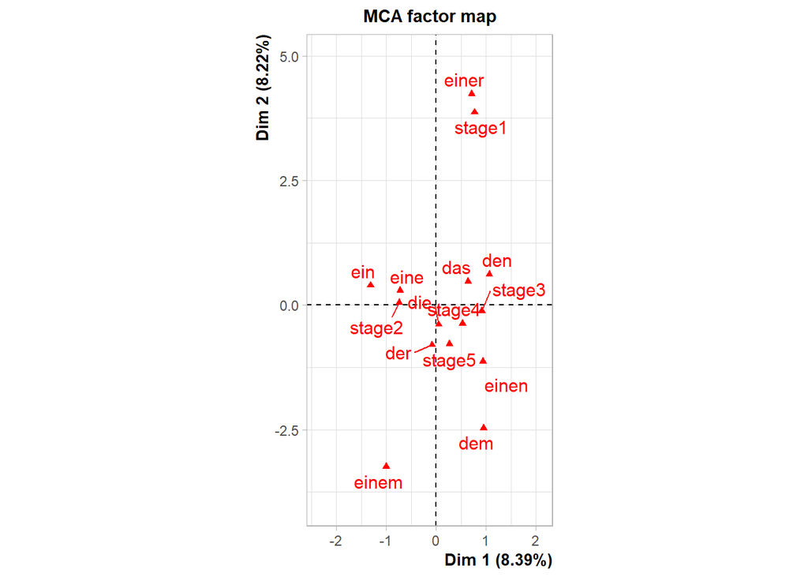

```r
plot(mca.1, invisible = "ind")
```

```r
library(factoextra)
```

‘fviz_mca_var()’ function is used to display the MCA graph of variable categories.

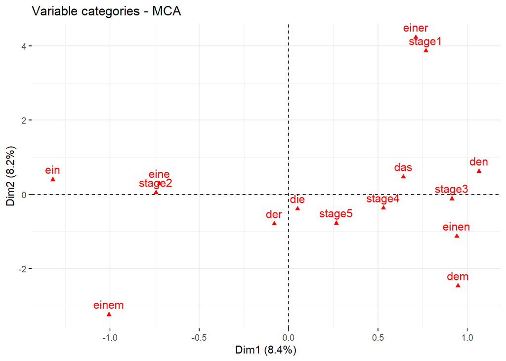

```r
fviz_mca_var(mca.1)
```

# Research question2

Which articles’ usage is high during childhood: Is it definite or indefinite?

### 1. Creating a subset dataframe for research question 2

#### 1.1. Copying the dataframe of research question 1

```r
childes.Ger.article.df2 <- childes.Ger.article.df1
head(childes.Ger.article.df2)
```

```
## # A tibble: 6 × 2
##   article stage
##   <chr>   <chr>
## 1 das     stage2
## 2 das     stage2
## 3 das     stage2
## 4 das     stage2
## 5 das     stage2
## 6 das     stage2
```

#### 1.2. Creating a new column for definite and indefinite articles

```r
childes.Ger.article.df2 <-  mutate(childes.Ger.article.df2, def = case_when(article %in% c("der","die","das","den","dem") ~ "definite", article %in% c("ein","eine","einen","einem","einer") ~ "indefinite" ))
```

#### 1.3. Selecting only required columns

```r
childes.Ger.article.df2 <- select(childes.Ger.article.df2, c(stage,def))

head(childes.Ger.article.df2)
```

```
## # A tibble: 6 × 2
##   stage  def
##   <chr>  <chr>
## 1 stage2 definite
## 2 stage2 definite
## 3 stage2 definite
## 4 stage2 definite
## 5 stage2 definite
## 6 stage2 definite
```

#### 1.4. Saving the dataframe

```r
write.xlsx(childes.Ger.article.df2, 'Rq2_dataset.xlsx',colNames=TRUE, rowNames=TRUE)
```

### 2. MCA analysis for research question 2

#### 2.1. Implementing MCA

```r
mca.2 <- MCA(childes.Ger.article.df2, graph = FALSE)

mca.2
```

```
## **Results of the Multiple Correspondence Analysis (MCA)**
## The analysis was performed on 172657 individuals, described by 2 variables
## *The results are available in the following objects:
##
##    name              description
## 1  "$eig"            "eigenvalues"
## 2  "$var"            "results for the variables"
## 3  "$var$coord"      "coord. of the categories"
## 4  "$var$cos2"       "cos2 for the categories"
## 5  "$var$contrib"    "contributions of the categories"
## 6  "$var$v.test"     "v-test for the categories"
## 7  "$var$eta2"       "coord. of variables"
## 8  "$ind"            "results for the individuals"
## 9  "$ind$coord"      "coord. for the individuals"
## 10 "$ind$cos2"       "cos2 for the individuals"
## 11 "$ind$contrib"    "contributions of the individuals"
## 12 "$call"           "intermediate results"
## 13 "$call$marge.col" "weights of columns"
## 14 "$call$marge.li"  "weights of rows"
```

#### 2.2. Summary of MCA

```r
summary(mca.2)
```

```
##
## Call:
## MCA(X = childes.Ger.article.df2, graph = FALSE)
##
##
## Eigenvalues
##                        Dim.1   Dim.2   Dim.3   Dim.4   Dim.5
## Variance               0.537   0.500   0.500   0.500   0.463
## % of var.             21.487  20.000  20.000  20.000  18.513
## Cumulative % of var.  21.487  41.487  61.487  81.487 100.000
##
## Individuals (the 10 first)
##               Dim.1    ctr   cos2    Dim.2    ctr   cos2    Dim.3    ctr   cos2
## 1          |  0.165  0.000  0.038 | -0.072  0.000  0.007 | -0.220  0.000  0.068
## 2          |  0.165  0.000  0.038 | -0.072  0.000  0.007 | -0.220  0.000  0.068
## 3          |  0.165  0.000  0.038 | -0.072  0.000  0.007 | -0.220  0.000  0.068
## 4          |  0.165  0.000  0.038 | -0.072  0.000  0.007 | -0.220  0.000  0.068
## 5          |  0.165  0.000  0.038 | -0.072  0.000  0.007 | -0.220  0.000  0.068
## 6          |  0.165  0.000  0.038 | -0.072  0.000  0.007 | -0.220  0.000  0.068
## 7          |  0.165  0.000  0.038 | -0.072  0.000  0.007 | -0.220  0.000  0.068
## 8          |  0.165  0.000  0.038 | -0.072  0.000  0.007 | -0.220  0.000  0.068
## 9          |  0.165  0.000  0.038 | -0.072  0.000  0.007 | -0.220  0.000  0.068
## 10         |  0.165  0.000  0.038 | -0.072  0.000  0.007 | -0.220  0.000  0.068
##
## 1          |
## 2          |
## 3          |
## 4          |
## 5          |
## 6          |
## 7          |
## 8          |
## 9          |
## 10         |
##
## Categories
##                 Dim.1      ctr     cos2   v.test      Dim.2      ctr     cos2
## stage1     |    0.516    0.769    0.009   38.364 |   -0.449    0.627    0.006
## stage2     |    0.676   20.574    0.428  271.706 |   -0.102    0.506    0.010
## stage3     |   -1.021   24.139    0.345 -244.113 |   -0.906   20.410    0.272
## stage4     |   -0.534    4.513    0.058 -100.418 |    2.068   72.639    0.875
## stage5     |    0.028    0.005    0.000    3.135 |   -0.929    5.817    0.062
## definite   |   -0.434   12.982    0.537 -304.540 |    0.000    0.000    0.000
## indefinite |    1.238   37.018    0.537  304.540 |    0.000    0.000    0.000
##              v.test      Dim.3      ctr     cos2   v.test
## stage1      -33.422 |   -0.437    0.593    0.006  -32.515 |
## stage2      -41.124 |   -0.312    4.692    0.091 -125.177 |
## stage3     -216.564 |   -0.496    6.110    0.081 -118.489 |
## stage4      388.692 |    0.263    1.174    0.014   49.413 |
## stage5     -103.777 |    3.602   87.431    0.937  402.320 |
## definite      0.000 |    0.000    0.000    0.000    0.000 |
## indefinite    0.000 |    0.000    0.000    0.000    0.000 |
##
## Categorical variables (eta2)
##              Dim.1 Dim.2 Dim.3
## stage      | 0.537 1.000 1.000 |
## def        | 0.537 0.000 0.000 |
```

#### 2.3. Visualizing the graph of MCA

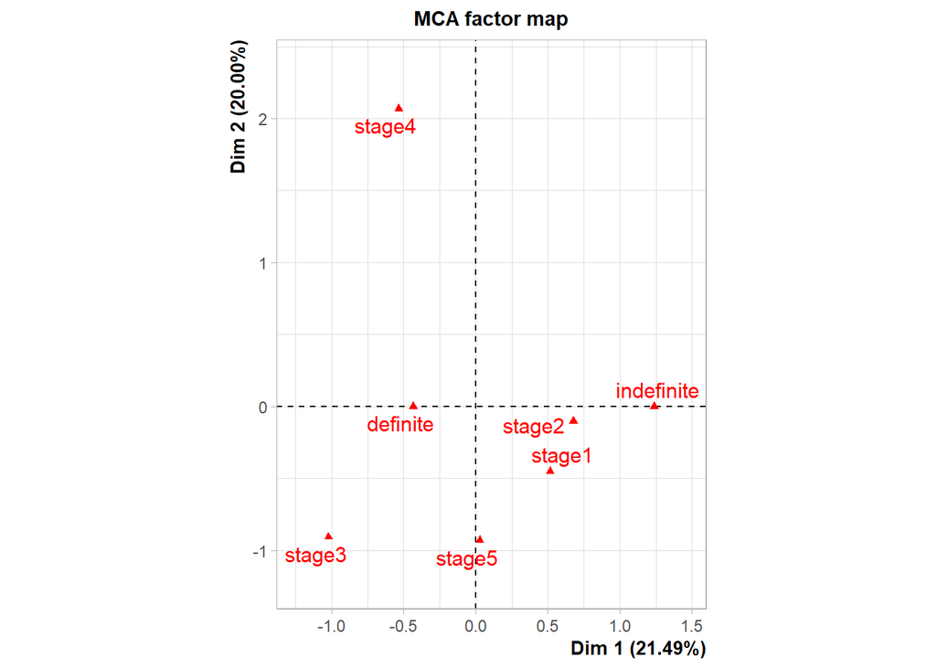

```r
plot(mca.2, invisible = "ind")
```

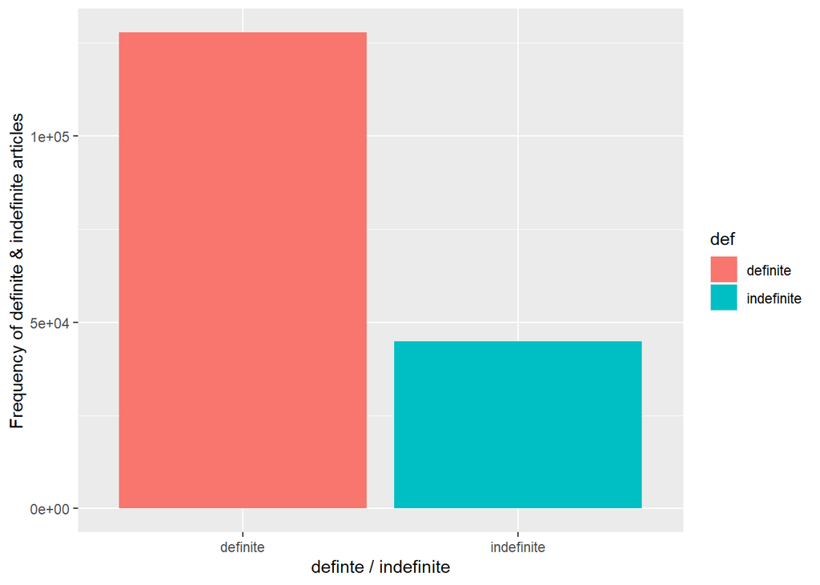

```r
ggplot(childes.Ger.article.df2, aes(x = def)) +
  geom_bar(stat = "count", aes(fill = def)) +
  labs(x = "definte / indefinite", y = "Frequency of definite & indefinite articles")
```

# Research question3

What is the overall usage of articles among children, is it more or less (by comparing it with adults’ usage)?

### 1. Creating a dataframe for research question3

#### 1.1. Copying the main dataframe

```r
childes.Ger.article.df3 <- childes.Ger.article.df
```

#### 1.2. Getting the values of ‘speaker_role’ column

```r
unique(childes.Ger.article.df3$speaker_role)
```

```
##  [1] "Investigator" "Mother"       "Grandfather"  "Target_Child" "Brother"
##  [6] "Father"       "Child"        "Relative"     "Grandmother"  "Friend"
## [11] "Visitor"      "Adult"        "Playmate"     "Sister"       "Teacher"
## [16] "Sibling"      "Unidentified" "Media"
```

#### 1.3. Removing the rows whose ‘speaker_role’ is not related to adults i.e., child, friend, playmate.

```r
childes.Ger.article.df3 <- filter(childes.Ger.article.df3, speaker_role != 'Child' & speaker_role != 'Friend' & speaker_role != 'Playmate')
```

#### 1.4. Adding new column called ‘speaker’

```r
childes.Ger.article.df3 <-  mutate(childes.Ger.article.df3, speaker = case_when(speaker_role %in% c("Investigator","Mother"   ,"Grandfather", "Brother","Father","Relative","Grandmother","Visitor", "Adult", "Sister", "Teacher", "Sibling", "Unidentified", "Media" ) ~ "adults", speaker_role == "Target_Child" ~ "children"))
```

#### 1.5. Changing the values of ‘article’ column into definite and indefinite.

Inorder to make the analysis clear and simple, the articles has been categorized into definite and indefinite instead of being der, die, das, etc.

```r
childes.Ger.article.df3 <-  mutate(childes.Ger.article.df3, article = case_when(article %in% c("der","die","das","den","dem") ~ "definite", article %in% c("ein","eine","einen","einem","einer") ~ "indefinite" ))
```

#### 1.6. Selecting only the required columns

```r
childes.Ger.article.df3 <- select(childes.Ger.article.df3, c(article,speaker))
head(childes.Ger.article.df3)
```

```
## # A tibble: 6 × 2
##   article  speaker
##   <chr>    <chr>
## 1 definite adults
## 2 definite adults
## 3 definite adults
## 4 definite adults
## 5 definite adults
## 6 definite adults
```

#### 1.7. Saving the dataframe

```r
write.xlsx(childes.Ger.article.df3, 'Rq3_dataset.xlsx',colNames=TRUE, rowNames=TRUE)
```

### 2. MCA analysis for research question3

#### 2.1. Implementing MCA

```r
mca.3 <- MCA(childes.Ger.article.df3, graph = FALSE)
mca.3
```

```
## **Results of the Multiple Correspondence Analysis (MCA)**
## The analysis was performed on 608304 individuals, described by 2 variables
## *The results are available in the following objects:
##
##    name              description
## 1  "$eig"            "eigenvalues"
## 2  "$var"            "results for the variables"
## 3  "$var$coord"      "coord. of the categories"
## 4  "$var$cos2"       "cos2 for the categories"
## 5  "$var$contrib"    "contributions of the categories"
## 6  "$var$v.test"     "v-test for the categories"
## 7  "$var$eta2"       "coord. of variables"
## 8  "$ind"            "results for the individuals"
## 9  "$ind$coord"      "coord. for the individuals"
## 10 "$ind$cos2"       "cos2 for the individuals"
## 11 "$ind$contrib"    "contributions of the individuals"
## 12 "$call"           "intermediate results"
## 13 "$call$marge.col" "weights of columns"
## 14 "$call$marge.li"  "weights of rows"
```

#### 2.2 Summary of MCA

```r
summary(mca.3)
```

```
##
## Call:
## MCA(X = childes.Ger.article.df3, graph = FALSE)
##
##
## Eigenvalues
##                        Dim.1   Dim.2
## Variance               0.528   0.472
## % of var.             52.820  47.180
## Cumulative % of var.  52.820 100.000
##
## Individuals (the 10 first)
##               Dim.1    ctr   cos2    Dim.2    ctr   cos2
## 1          | -0.582  0.000  0.993 |  0.047  0.000  0.007 |
## 2          | -0.582  0.000  0.993 |  0.047  0.000  0.007 |
## 3          | -0.582  0.000  0.993 |  0.047  0.000  0.007 |
## 4          | -0.582  0.000  0.993 |  0.047  0.000  0.007 |
## 5          | -0.582  0.000  0.993 |  0.047  0.000  0.007 |
## 6          | -0.582  0.000  0.993 |  0.047  0.000  0.007 |
## 7          | -0.582  0.000  0.993 |  0.047  0.000  0.007 |
## 8          |  0.527  0.000  0.198 | -1.062  0.000  0.802 |
## 9          | -0.582  0.000  0.993 |  0.047  0.000  0.007 |
## 10         |  0.527  0.000  0.198 | -1.062  0.000  0.802 |
##
## Categories
##                 Dim.1      ctr     cos2   v.test      Dim.2      ctr     cos2
## definite   |   -0.389   11.120    0.528 -566.839 |   -0.367   11.120    0.472
## indefinite |    1.359   38.880    0.528  566.839 |    1.284   38.880    0.472
## adults     |   -0.458   14.192    0.528 -566.839 |    0.432   14.192    0.472
## children   |    1.154   35.808    0.528  566.839 |   -1.091   35.808    0.472
##              v.test
## definite   -535.721 |
## indefinite  535.721 |
## adults      535.721 |
## children   -535.721 |
##
## Categorical variables (eta2)
##              Dim.1 Dim.2
## article    | 0.528 0.472 |
## speaker    | 0.528 0.472 |
```

#### 2.3. Visualizing the graph of MCA

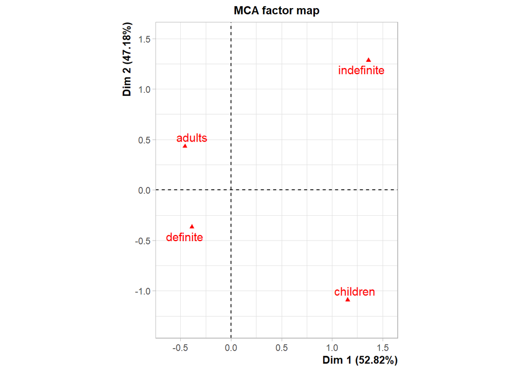

```r
plot(mca.3, invisible = "ind")
```

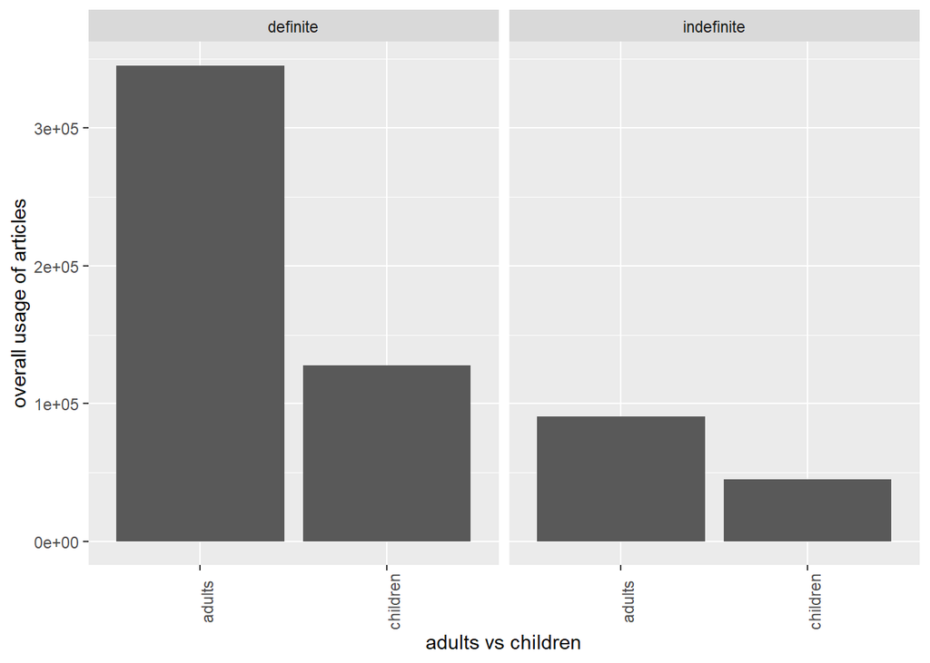

```r
ggplot(childes.Ger.article.df3, aes(x = speaker)) +
       geom_bar(stat = "count") +
   facet_wrap(~article) +
  labs(x = "adults vs children", y = "overall usage of articles") +
    theme(axis.text.x = element_text(angle = 90))
```

#### checking the count of definite and indefinite articles against speaker(adults and children)

```r
count <- childes.Ger.article.df3 %>% count(speaker, article)
count
```

```
## # A tibble: 4 × 3
##   speaker  article         n
##   <chr>    <chr>       <int>
## 1 adults   definite   345196
## 2 adults   indefinite  90451
## 3 children definite   127827
## 4 children indefinite  44830
```

## Additional commands

### Retrieving transcripts of ‘den’ for stage3

```r
den.utterence_stage3 <- get_utterances(collection = "German", age = c(36, 48))
```

```
## Using current database version: '2021.1'.
```

```
## Getting data from 134 children in 13 corpora...
```

```r
den.utterence_stage3 <- select(den.utterence_stage3, c(id, gloss,speaker_role,target_child_name,target_child_age,corpus_name))
```

```r
den.utterence_stage3 <- filter(den.utterence_stage3, grepl("\\bden\\b", gloss, ignore.case = TRUE))
```

```r
den.utterence_stage3 <- filter(den.utterence_stage3, corpus_name == "Miller" )

write.xlsx(den.utterence_stage3, 'den_uttr_stage3.xlsx',colNames=TRUE, rowNames=TRUE)
```

### Retrieving transcripts of ‘dem’ for stage3

```r
dem.utterence_stage3 <- get_utterances(collection = "German", age = c(36, 48))
```

```
## Using current database version: '2021.1'.
```

```
## Getting data from 134 children in 13 corpora...
```

```r
dem.utterence_stage3 <- select(dem.utterence_stage3, c(id, gloss,speaker_role,target_child_name,target_child_age,corpus_name))
```

```r
dem.utterence_stage3 <- filter(dem.utterence_stage3, grepl("\\bdem\\b", gloss, ignore.case = TRUE))
```

```r
dem.utterence_stage3 <- filter(dem.utterence_stage3, corpus_name == "Miller" )

write.xlsx(dem.utterence_stage3, 'dem_uttr_stage3.xlsx',colNames=TRUE, rowNames=TRUE)
```